# d238U inverse model

Michael Kipp

August 30, 2021

This R Markdown document walks through the workflow of fitting a d238U dataset using the MCMC routine described in Kipp & Tissot (2021) EPSL. Users are directed to the paper for a full description of the background and rationale.

## Part I: Getting started

First we’ll load a few necessary packages:

```r
library(msir)
library(FME)
library(doParallel)
library(LaplacesDemon)
```

Next we’ll set our working directory and read in our dataset:

```r
setwd("/Users/MichaelKipp/Downloads")
current_dataset=read.csv("jost_2017_Triassic_data.csv",header=T,stringsAsFactors=F)
```

And we’ll quickly plot our dataset with a LOESS curve to get a sense for any trends in the data:

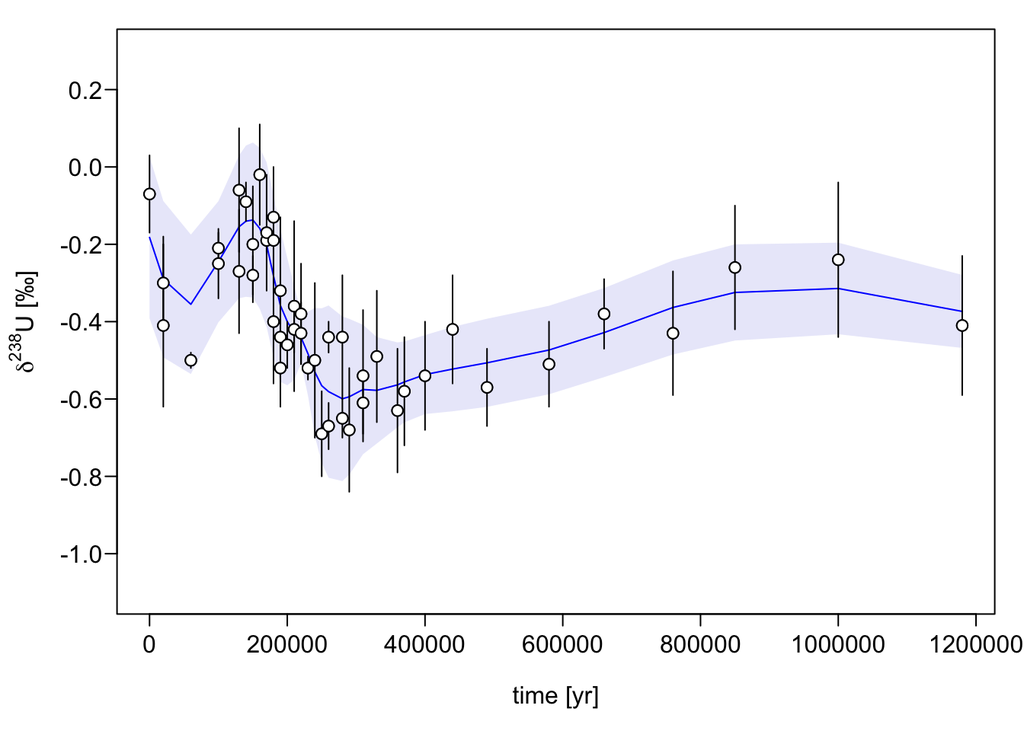

```r
par(mfrow=c(1,1))
par(mar=c(4,4,1,1))
par(oma=c(0,0,0,0))
plot(current_dataset$d238U~current_dataset$time,axes=F,xlab="",ylab="",ylim=c(-1.1,0.3))
loess_mod=loess.sd(current_dataset$d238U~current_dataset$time,span=0.4,nsigma=2)
polygon(c(loess_mod$x,rev(loess_mod$x)),c(loess_mod$upper,rev(loess_mod$lower)),col=rgb(0,0,0.8,0.1),border=F)
lines(loess_mod$y~loess_mod$x,col="blue")
arrows(current_dataset$time,current_dataset$d238U+(2*current_dataset$err),current_dataset$time,current_dataset$d238U-(2*current_dataset$err),length=0)
points(current_dataset$d238U~current_dataset$time,pch=21,bg="white")
axis(side=1,mgp=c(3,0.5,0),las=1,tck=-0.02)
axis(side=2,mgp=c(3,0.5,0),las=1,tck=-0.02)
mtext("time [yr]",side=1,line=2.25)
mtext(expression(delta^{238}*"U [\u2030]"),side=2,line=2.5)
box(lwd=1)
```

#### Model parameters

Now we’ll define the parameters for the d238U mass balance model.

These are parameters we’ll definitely want to tune:

```r
time_step=10e3 # size of time-steps; should be at minimum 1e3; must match temporal resolution of data
prop_uncert=F # propagate uncertainty on terms in mass balance? yes=T, no=F [start no for testing, use yes at end]
m=6 # number of terms in Fourier series [start low, demonstrate convergence, increase if needed, test convergence again, repeat...]
niterMCMC=2e6 # number of steps per walker [likely needs to be 10^5-10^6; start at 10^3 and see how long it will take]
updatecovMCMC=2e3 # number of steps after which covariance matrix is updated (only during burn-in phase) [see table in ReadMe]
n_walkers=5 # number of parallel walkers deployed [aim for 3-5 in initial tests, 100+ if propagating uncertainty]
```

These are parameters we might not have to tune if we’re lucky:

```r
amp_limit=2e-5 # range for amplitude terms [decrease if low acceptance persists]
start=1 # start of frequency terms; 1 for odd harmonics or continuous, 2 for even harmonics [default=1]
count=2 # spacing of frequency terms; 2 for odd or even harmonics, 1 for continuous [default=2]
jump_step_1=amp_limit*0.05 # SD of proposal distribution for amplitude terms [default=amp_limit*0.05]
jump_step_2=0.2 # SD of proposal distribution for log_fanox_0 [default=0.2]
burninlengthMCMC=niterMCMC-1e3 # number of discarded "burn in" steps [1e3 less than niterMCMC typically works well]
thin=1 # factor by which final output is "thinned"; 1=no thinning, 10=keep every 10th sample [default=1]
```

These are parameters we’ll never have to tune:

```r
start_time=min(current_dataset$time)
max_time=max(current_dataset$time)+(time_step-start_time)
a_vals=seq(0,0,length.out=m)
b_vals=seq(0,0,length.out=m)
as=paste("a",1:m,sep="")
bs=paste("b",1:m,sep="")
names(a_vals)=as
names(b_vals)=bs
pars1=c(log_fanox_0=-2.67,a_vals,b_vals) # starting values; gives modern mass balance
upper=c(0,seq(amp_limit, amp_limit,length=2*m)) # upper limits
lower=c(-4,seq(-amp_limit,-amp_limit,length=2*m)) # lower limits
jump=c(jump_step_2,seq(jump_step_1,jump_step_1,length=2*m))
```

Here, we define a matrix that equates `d238Usw` and `fanox` at steady state. This matrix is used to generate consistent steady-state scenarios at the beginning of each time series.

```r
Jriv=0.42e8 # Dunk et al (2002) Chem Geol
Kanox=1.74e-4 # derived in Kipp & Tissot (2021) EPSL
Kother=1.88e-6  # derived in Kipp & Tissot (2021) EPSL
d238Uriv=-0.30 # Tissot et al (2015); Andersen et al (2016) Chem Geol
Danox=0.6 # widely-used value, see e.g. Zhang et al (2020) GCA
Dother=0 # widely-used value, see e.g. Zhang et al (2020) GCA
fanox_seq=10^seq(-5,0,length=1000)
log_fanox_seq=seq(-5,0,length=1000)
d238U_SS=d238Uriv-(((Jriv/((Kanox*fanox_seq)+Kother*(1-fanox_seq)))*((Kother*Dother)+(fanox_seq*((Kanox*Danox)-(Kother*Dother)))))/Jriv)
ss_out=cbind(d238U_SS, log_fanox_seq)
```

## Part II: Forward model

In Part I, we uploaded a dataset and set the model parameters. Now we will define the forward model:

```r
d238U_model=function(pars){
    derivs=function(time,y,pars){
        with(as.list(c(pars,y)),{
            dd238Usw=(Jriv*(d238Uriv-d238Usw)-Kanox*Nsw*(10^log_fanox)*Danox-Kother*Nsw*(1-(10^log_fanox))*Dother)/Nsw
            dNsw=Jriv-Kanox*Nsw*(10^log_fanox)-Kother*Nsw*(1-(10^log_fanox))
            dlog_fanox=if(log_fanox>-0.004){-1e-8} else if(abs(log_fanox)>4){1e-8} else {sum((pars[seq(2,by=1,length.out=m)]*sin(seq(start,length.out=m,by=count)*pi*time/max_time))+(pars[seq(2+m,by=1,length.out=m)]*cos(seq(start,length.out=m,by=count)*pi*time/max_time)))}

            return(list(c(dd238Usw,dNsw,dlog_fanox)))
        })
    }

log_fanox_0=with(as.list(pars),log_fanox_0)
Nsw_0=with(as.list(pars),Jriv/(Kanox*(10^log_fanox_0)+Kother*(1-(10^log_fanox_0))))
d238Usw_0=with(as.list(pars),as.numeric((ss_out[ss_out[,2]>=log_fanox_0,])[1]))

y=c(d238Usw=d238Usw_0,Nsw=Nsw_0,log_fanox=log_fanox_0)

times=seq(start_time,max_time,by=time_step)
out=ode(y=y,parms=pars,times=times,func=derivs,method="euler")

as.data.frame(out)
}
```

We can check that the forward model works properly by running it with the modern steady-state values (`pars1`) as our input. We should get 3 straight lines (at the modern SS values) for `d238Usw`, `Nsw` and `fanox`.

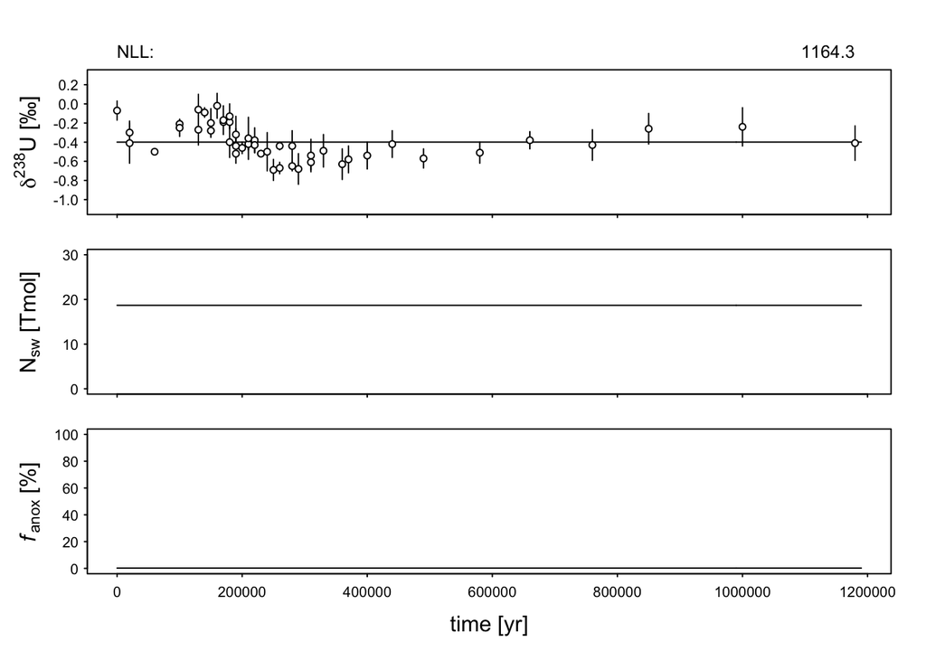

```r
out1=d238U_model(pars=pars1)

mergeout=merge(out1,current_dataset,by="time")
start_NLL=round((sum(0.5*log(2*pi*mergeout$err))+sum(na.omit(((mergeout$d238U-mergeout$d238Usw)^2)/(mergeout$err^2)))),digits=1)  # NLL of starting model (modern SS)

par(mfrow=c(3,1))
par(mar=c(1,1,1,1))
par(oma=c(4,4,3,1))
plot(out1$d238Usw~out1$time,type="l",ylim=c(-1.1,0.3),axes=F,xlab="",ylab="")
arrows(current_dataset$time,current_dataset$d238U+current_dataset$err*2,current_dataset$time,current_dataset$d238U-current_dataset$err*2,length=0)
points(current_dataset$d238U~current_dataset$time,pch=21,bg="white")
axis(side=1,tck=-0.02,mgp=c(3,0.5,0),las=1,labels=NA)
axis(side=2,tck=-0.02,mgp=c(3,0.5,0),las=1)
box(lwd=1)
mtext(side=2,line=2.5,expression(delta^{238}*"U [\u2030]"))
mtext(side=3,line=0.5,"NLL:",at=min(current_dataset$time),adj=0,cex=0.8)
mtext(side=3,line=0.5,paste(start_NLL),at=max(current_dataset$time),adj=1,cex=0.8)
plot(out1$Nsw~out1$time,type="l",ylim=c(0,3e13),axes=F,xlab="",ylab="")
axis(side=1,tck=-0.02,mgp=c(3,0.5,0),las=1,labels=NA)
axis(side=2,tck=-0.02,mgp=c(3,0.5,0),las=1,at=c(0,10e12,20e12,30e12),labels=c(0,10,20,30))
box(lwd=1)
mtext(side=2,line=2.5,expression("N"[sw]*" [Tmol]"))
plot(100*10^out1$log_fanox~out1$time,type="l",ylim=c(0,100),axes=F,xlab="",ylab="")
axis(side=1,tck=-0.02,mgp=c(3,0.5,0),las=1)
axis(side=2,tck=-0.02,mgp=c(3,0.5,0),las=1)
box(lwd=1)
mtext(side=1,line=2.5,"time [yr]")
mtext(side=2,line=2.5,expression(italic("f")[anox]*" [%]"))
```

## Part III: Inverse model

Having defined the forward model, we can now build the MCMC routine that will be used to optimize the forward model fit to the dataset.

First we need to define the cost function (negative log-likelihood, NLL):

```r
d238Ucost=function(pars){
    out1=d238U_model(pars=pars)
    merged=merge(out1,current_dataset,by="time")
    NLL=log(2*pi*merged$err)+na.omit(((merged$d238U-merged$d238Usw)^2)/(merged$err^2))
    return(sum(NLL))
}
```

Then we’ll set up parallel computation so that different walkers (or “chains”) can run on different cores:

```r
cores=detectCores()
cl=makeCluster(cores[1]-1)
registerDoParallel(cl)
```

And then we can run the MCMC routine:

```r
start.time=Sys.time()
finalMCMC=foreach(i=1:n_walkers,.combine=rbind) %dopar% {

library(FME)

if(prop_uncert==T){

Kanox=rnorm(1,1.74e-4,0.655e-4) # derived in Kipp & Tissot (2021) EPSL
Kother=35.7e6/(19e12*(1-(6.3e6/(19e12*Kanox))))  # derived in Kipp & Tissot (2021) EPSL
d238Uriv=rnorm(1,-0.30,0.02) # Tissot et al (2015); Andersen et al (2016) Chem Geol
Danox=rnorm(1,0.6,0.1) # widely-used value, see e.g. Zhang et al (2020) GCA
Dother=rnorm(1,0,0.025) # widely-used value, see e.g. Zhang et al (2020) GCA

}

fanox_seq=10^seq(-5,0,length=1000)
log_fanox_seq=seq(-5,0,length=1000)
d238U_SS=d238Uriv-(((Jriv/((Kanox*fanox_seq)+Kother*(1-fanox_seq)))*((Kother*Dother)+(fanox_seq*((Kanox*Danox)-(Kother*Dother)))))/Jriv)
ss_out=cbind(d238U_SS, log_fanox_seq)

curMCMC=modMCMC(f=d238Ucost,p=pars1,niter=niterMCMC,lower=lower,upper=upper,jump=jump,prior=NULL,var0=NULL,wvar0=0.1,updatecov=updatecovMCMC,burninlength=burninlengthMCMC)

tempMatrix=cbind(curMCMC$par)
tempMatrix

}
end.time=Sys.time()
run.time1=end.time-start.time
run.time1
```

```
## Time difference of 2.195588 hours
```

```r
stopCluster(cl)
```

We can now optionally thin our output to make it more computationally tractable, though in most cases we set `thin` = 1 (retain all samples). We also write the output as a `.csv` file so that it is saved for any future needs.

```r
thin_count=dim(finalMCMC)[1]/thin
i=1
new_out=NULL
for (i in 1:thin_count){
    cur_vals=finalMCMC[i*thin,]
    new_out=rbind(new_out,cur_vals)
}

write.csv(new_out,"MCMC_out.csv")
MCMC_out=read.csv("MCMC_out.csv")
MCMC_out=MCMC_out[,2:dim(MCMC_out)[2]]
```

We now have posterior parameter distributions that we can iteratively sample in order to generate a reconstructed time series (and uncertainty range) for the variables of interest (`d238Usw`, `Nsw`, `Fanox`, `fanox`):

```r
start.time=Sys.time()

i=1
n_reps=1e3 # 1e3 is sufficient for final run; can decrease to 1e2 for testing
time_seq=seq(start_time,max_time,by=time_step)
d238Usw_out=NULL
Nsw_out=NULL
fanox_out=NULL
for (i in 1:n_reps){

    if(prop_uncert==T){

    Kanox=rnorm(1,1.74e-4,0.655e-4) # derived in Kipp & Tissot (2021) EPSL
    Kother=35.7e6/(19e12*(1-(6.3e6/(19e12*Kanox))))  # derived in Kipp & Tissot (2021) EPSL
    d238Uriv=rnorm(1,-0.30,0.02) # Tissot et al (2015); Andersen et al (2016) Chem Geol
    Danox=rnorm(1,0.6,0.1) # widely-used value, see e.g. Zhang et al (2020) GCA
    Dother=rnorm(1,0,0.025) # widely-used value, see e.g. Zhang et al (2020) GCA

    }

    fanox_seq=10^seq(-5,0,length=1000)
    log_fanox_seq=seq(-5,0,length=1000)
    d238U_SS=d238Uriv-(((Jriv/((Kanox*fanox_seq)+Kother*(1-fanox_seq)))*((Kother*Dother)+(fanox_seq*((Kanox*Danox)-(Kother*Dother)))))/Jriv)
    ss_out=cbind(d238U_SS, log_fanox_seq)

    sr1=sensRange(fun=d238U_model,parms=NULL,parInput= MCMC_out,num=1)
    d238Usw_sens=sr1[,(length(pars1)+1):(length(pars1)+length(time_seq))]
    Nsw_sens=sr1[,(length(pars1)+1+length(time_seq)):(length(pars1)+2*length(time_seq))]
    fanox_sens=sr1[,(length(pars1)+1+2*length(time_seq)):(length(pars1)+3*length(time_seq))]

    d238Usw_out=rbind(d238Usw_out, d238Usw_sens)
    Nsw_out=rbind(Nsw_out, Nsw_sens)
    fanox_out=rbind(fanox_out, fanox_sens)
}


i=1
d238Usw_quant_out=NULL
Nsw_quant_out=NULL
fanox_quant_out=NULL

for (i in 1:length(time_seq)){
    cur_time=time_seq[i]
    cur_d238Usw_quant=quantile(na.omit(d238Usw_out[,i]),probs=seq(0.01,1,by=0.01))
    cur_Nsw_quant=quantile(na.omit(Nsw_out[,i]),probs=seq(0.01,1,by=0.01))
    cur_fanox_quant=quantile(na.omit(fanox_out[,i]),probs=seq(0.01,1,by=0.01))
    d238Usw_quant_out=rbind(d238Usw_quant_out, cur_d238Usw_quant)
    Nsw_quant_out=rbind(Nsw_quant_out, cur_Nsw_quant)
    fanox_quant_out=rbind(fanox_quant_out, cur_fanox_quant)
}


end.time=Sys.time()
run.time2=end.time-start.time
run.time2
```

```
## Time difference of 5.200321 mins
```

## Part IV: Plotting recovered d238Usw, Nsw, Fanox and fanox trends

Now we can plot our results. We’ll first calculate some statistics that will help us assess whether our run converged on the target distribution:

```r
mcmcout=cbind(time_seq,d238Usw_quant_out[,50])
colnames(mcmcout)=c("time","d238Usw")
mergemcmc=merge(mcmcout,current_dataset,by="time")
total_NLL=round((sum(0.5*log(2*pi*mergemcmc$err))+sum(na.omit(((mergemcmc$d238U-mergemcmc$d238Usw)^2)/(mergemcmc$err^2)))),digits=1)  # final NLL of median output
accept_frac=100*round(length(unique(finalMCMC[,1]))/length(finalMCMC[,1]),digits=2) # fraction of steps accepted during random walks
z=1
y=1
auto_out=NULL
big_auto_out=NULL
mcmc_list_out=NULL
for (z in 1:n_walkers){
    cur_walker_data=finalMCMC[(1+(((niterMCMC-burninlengthMCMC)/thin)*(z-1))):(((niterMCMC-burninlengthMCMC)/thin)*(z)),]

    y=1
    for (y in 1:(dim(cur_walker_data)[2]-2)){
        cur_autocorr=IAT(as.numeric(cur_walker_data[,y]))
        auto_out=rbind(auto_out,cur_autocorr)
    }

    cur_avg_autocorr=mean(auto_out)
    cur_eff=((niterMCMC-burninlengthMCMC)/thin)/cur_avg_autocorr
    results=c(cur_avg_autocorr, cur_eff)
    big_auto_out=rbind(big_auto_out, results)

    mcmc_results=cbind(cur_walker_data,z)
    mcmc_list_out=rbind(mcmc_list_out,mcmc_results)


}
avg_autocorr_MCMC=mean(big_auto_out[,1]) # average integrated autocorrelation time (IAT)
eff=round(sum(big_auto_out[,2]),digits=0) # effective sample size (total samples/IAT)
mcmc_out_1=mcmc(mcmc_list_out[mcmc_list_out[,dim(mcmc_list_out)[2]]==1,],thin=thin)
mcmc_out_1= mcmc_out_1[,1:length(pars1)]
mcmc_out_2=mcmc(mcmc_list_out[mcmc_list_out[,dim(mcmc_list_out)[2]]==2,],thin=thin)
mcmc_out_2= mcmc_out_2[,1:length(pars1)]
mcmc_out_3=mcmc(mcmc_list_out[mcmc_list_out[,dim(mcmc_list_out)[2]]==3,],thin=thin)
mcmc_out_3= mcmc_out_3[,1:length(pars1)]
mcmc_out_4=mcmc(mcmc_list_out[mcmc_list_out[,dim(mcmc_list_out)[2]]==4,],thin=thin)
mcmc_out_4= mcmc_out_4[,1:length(pars1)]
mcmc_out_5=mcmc(mcmc_list_out[mcmc_list_out[,dim(mcmc_list_out)[2]]==5,],thin=thin)
mcmc_out_5= mcmc_out_5[,1:length(pars1)]
mcmc_list=as.mcmc.list(list(mcmc_out_1,mcmc_out_2,mcmc_out_3,mcmc_out_4,mcmc_out_5))
psrf=gelman.diag(mcmc_list,autoburnin=FALSE) # calculating potential scale reduction factor (psrf), i.e. Gelman-Rubin statistic, or Rhat
avg_psrf=round(mean(psrf$psrf[,1]),digits=2) # average psrf for all variables (gives quick check of convergence; aiming for <<1.2)
```

And finally, we will plot our recovered trends. The median output is shown in the solid black line, with the 16th to 84th percentile region in grey shading:

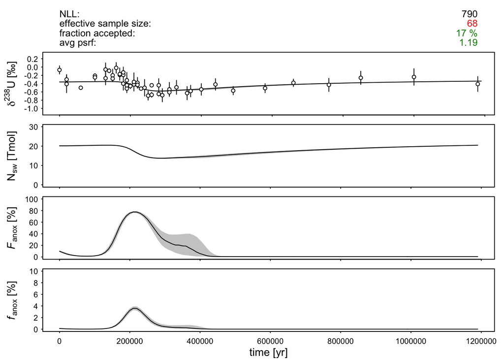

```r
par(mfrow=c(4,1))
par(mar=c(0.5,1,0.5,1))
par(oma=c(2.5,3.5,5,0))
plot(current_dataset$d238U~current_dataset$time,ylim=c(-1.1,0.3),cex=0,axes=F,xlab="",ylab="")
polygon(c(time_seq,rev(time_seq)),c(d238Usw_quant_out[,16],rev(d238Usw_quant_out[,84])),border=F,col="grey80")
lines(d238Usw_quant_out[,50]~ time_seq,col="black")
arrows(current_dataset$time,current_dataset$d238U+current_dataset$err*2,current_dataset$time,current_dataset$d238U-current_dataset$err*2,length=0)
points(current_dataset$d238U~current_dataset$time,pch=21,bg="white",cex=1.0)
axis(side=2,tck=-0.02,mgp=c(3,0.5,0),las=1,)
axis(side=1,tck=-0.02,mgp=c(3,0.5,0),las=1,labels=NA)
mtext(expression(delta^{238}*"U [\u2030]"),side=2,line=2.5,cex=0.9)
box(lwd=1)
mtext(side=3,line=3.5,"NLL:",at=min(current_dataset$time),adj=0,cex=0.8)
mtext(side=3,line=3.5,paste(total_NLL),at=max(current_dataset$time),adj=1,cex=0.8)
mtext(side=3,line=2.5,"effective sample size:",at=min(current_dataset$time),adj=0,cex=0.8)
mtext(side=3,line=2.5,paste(eff),at=max(current_dataset$time),col=if((eff>=1000)){"green4"} else if(eff>=100){"orange"} else{"red"},adj=1,cex=0.8)
mtext(side=3,line=1.5,"fraction accepted:",at=min(current_dataset$time),adj=0,cex=0.8)
mtext(side=3,line=1.5,paste(accept_frac,"%"),at=max(current_dataset$time),col=if((accept_frac>=10)&(accept_frac<=50)){"green4"} else if((accept_frac<10)&(accept_frac>=5)){"orange"} else if((accept_frac>50)&(accept_frac<=60)){"orange"} else{"red"},adj=1,cex=0.8)
mtext(side=3,line=0.5,"avg psrf:",at=min(current_dataset$time),adj=0,cex=0.8)
mtext(side=3,line=0.5,paste(avg_psrf),at=max(current_dataset$time),col=if(avg_psrf<=1.2){"green4"} else if((avg_psrf>1.2)&(avg_psrf<=1.5)){"orange"} else{"red"},adj=1,cex=0.8)

plot(Nsw_quant_out[,50]~time_seq,ylim=c(0,3e13),cex=0,axes=F,xlab="",ylab="")
polygon(c(time_seq,rev(time_seq)),c((Nsw_quant_out[,16]),rev(Nsw_quant_out[,84])),border=F,col="grey80")
lines(Nsw_quant_out[,50]~time_seq,col="black")
axis(side=2,tck=-0.02,mgp=c(3,0.5,0),las=1,at=c(0,10e12,20e12,30e12),labels=c("0","10","20","30"))
axis(side=1,tck=-0.02,mgp=c(3,0.5,0),las=1,labels=NA)
mtext(expression("N"[sw]*" [Tmol]"),side=2,line=2.5,cex=0.9)
box(lwd=1)

plot(10^fanox_quant_out[,4]~time_seq,ylim=c(0,100),cex=0,axes=F,xlab="",ylab="")
Fanox_quant_out=(10^fanox_quant_out*Kanox)/(10^fanox_quant_out*Kanox+Kother*(1-10^fanox_quant_out))
polygon(c(time_seq,rev(time_seq)),c((100*Fanox_quant_out[,16]),rev(100*Fanox_quant_out[,84])),border=F,col="grey80")
lines(100*Fanox_quant_out[,50]~time_seq,col="black")
axis(side=2,tck=-0.02,mgp=c(3,0.5,0),las=1)
axis(side=1,tck=-0.02,mgp=c(3,0.5,0),las=1,labels=NA)
mtext(expression(italic("F")[anox]*" [%]"),side=2,line=2.5,cex=0.9)
box(lwd=1)

plot(10^fanox_quant_out[,4]~time_seq,ylim=c(0,10),cex=0,axes=F,xlab="",ylab="")
polygon(c(time_seq,rev(time_seq)),c((100*10^fanox_quant_out[,16]),rev(100*10^fanox_quant_out[,84])),border=F,col="grey80")
lines(100*10^fanox_quant_out[,50]~time_seq,col="black")
axis(side=2,tck=-0.02,mgp=c(3,0.5,0),las=1)
axis(side=1,tck=-0.02,mgp=c(3,0.5,0),las=1)
mtext(expression(italic("f")[anox]*" [%]"),side=2,line=2.5,cex=0.9)
mtext("time [yr]",side=1,line=1.75,cex=0.9)
box(lwd=1)
```

We’ve now run the complete inverse model. If we haven’t converged on the target distribution for all parameters (i.e., psrf > 1.2), we can first try running for longer (higher `niterMCMC` value), using fewer terms (lower `m` value), or tuning the `updatecovMCMC` value. If convergence is still difficult (at this point, likely also indicated by low acceptance fraction, <<10%), we can shrink the range of possible parameter values (`amp_limit`) by a factor of 2-10. In rare cases, we might also have better luck actually moving to higher `m` values.

Once convergence is achieved (psrf << 1.2), we can feel confident that the MCMC has found the best fit to the dataset given our parameterization. If the recovered trend does not capture all of the subtleties in the dataset, though, we may consider repeating the calculations with a larger `m` value. This will necessitate a longer run for convergence, but might result in a better fit to the data (lower NLL). Once we are convinced that we’ve used a high enough `m` value (i.e., NLL no longer decreases with an increase in `m`), we finally want to (1) propagate uncertainty on the terms in the mass balance, and (2) increase our effective sample size (should be able to reach >1000). To do so, switch `prop_uncert` to TRUE and set `n_walkers` to at least 100. This will likely be a very long run! So best to leave the computer overnight, or send this task off to a computing cluster for parallel processing.

For persistent problems, or to report bugs or make suggestions, reach out to Michael Kipp (mkipp@caltech.edu).